# QBS 177 Final Project - Hemorrhage Research

Spencer Bertsch  
Feb. 2022

Some helpful commands:  
* Insert a new code chunk: *Cmd+Option+I*  
* Run a code cell: *Cmd+Shift+Enter*  
* Preview the notebook HTML file: *Cmd+Shift+K*

### Imports

```r
library(glue)
library(glmnet)
```

First we need to change our current working directory to the correct directory for Assignment 3

```r
setwd('/Users/spencerbertsch/Desktop/dev/phd_courses/MATH177/final_project')
getwd()
```

```
[1] "/Users/spencerbertsch/Desktop/dev/phd_courses/MATH177/final_project"
```

```r
df <- read.csv("log_lasso_exports/df_log_lasso_swisstom_thorax.csv")
```

```r
# define X_df and y_df
y_df <- as.matrix(df[,100])
X_df <- as.matrix(df[,2:99])
```

We can now apply the binomial elastic net model to the training data using the glmnet r library.

```r
fit <- glmnet(X_df, y_df, family = "binomial")
```

We can also use cvfit to use cross validation on our training data.

```r
cvfit <- cv.glmnet(X_df, y_df, family = "binomial", type.measure = "class")
```

We can now plot the results from our cross validation model.

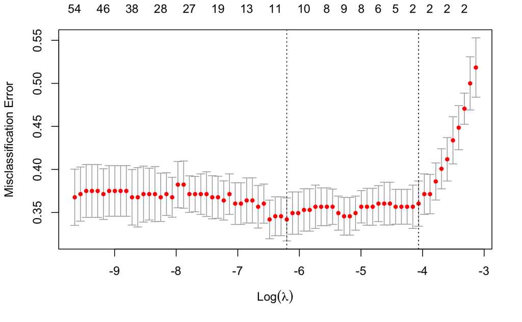

```r
plot(cvfit)
```

# Find Columns to Model

We now want to create an empty matrix filled with zeros so that we can populate the matrix later on. We can do that with the `matrix` command in r. We want out matrix to have 98 rows and 100 columns.

```r
# create the coefout matrix with dimensions [7399 x 100] - initialize the matrix as a zero matrix
coefout <- matrix(0, 98, 100)
```

Now that we have our coefout matrix initialized, we can run the loop that populates it.

```r
# loop 100 times, once for each of the trials
start.time <- Sys.time()
iterations <- 50 # <-- we can always change this to 100 for more confidence
  for (i in 1:iterations){

    # create an array of integers that represent the sample IDs for 180 samples
    id <- sample(1:272, 180)

    # subset out training data to only include the samples chosen above
    data1 <- X_df[id, ]

    # we can now isolate the column that contains the survival times (I assume years survived)
    response <- y_df[id, ]

    # we now convert our x_train subset into a matrix
    x <- as.matrix(data1)

    # here we fit the binomial Lasso model
    fit2 <- glmnet(x, response, family = "binomial")

    # and here we perform a cross validation for our lasso model across many values for lambda.
    # just because we use Lasso here doesn't mean we know the best value for Lambda (that's what we find here)
    cvfit = cv.glmnet(x, response, family = "binomial", type.measure = "class")

    # some optimal plotting and data inspection - we don't want to do this at each iteration in the loop
    #plot(cvfit)
    #cvfit$lambda.min

    # here we find the coefficient values for our Lasso model. Remember this is Lasso, not Ridge! So many
    # of the values here should be zero
    coef.min = coef(cvfit, s = "lambda.min")[-1]

    # and lastly we can take the coefficients that are NOT zero and add them to the coefout outside of the loop
    coefout[,i] <- as.numeric(coef.min!=0)

    # we can use these two lines to find the coefficients that were non-zero
    #active.min = which(coef.min != 0)
    #index.min = coef.min[active.min]

  }
```

[output not shown]

[output cut: 340 more lines]

```r
end.time <- Sys.time()
time.taken <- end.time - start.time
print(time.taken)
```

```
Time difference of 7.80047 mins
```

We can then find the mean or the sum of the columns in our coefout matrix and sort the results to find the columns that were used the most by the logistic lasso model.

```r
# define K to limit the number of columns kept
K = 5

# here we take the sum along the columns of the coefout matrix
# coeffout1 gives us a vector of length 98 in which we have a value for each predictor variable. The larger
# the value, the more times that predictor was chosen by Lasso during the 100 trials in the previous step.
coefout1 <- apply(coefout, 1, sum)

# here we use the value of K to only take the top (most important) predictors for use in the stepwise
# regression model
# we only keep values here if they were chosen by more than K trials of our Lasso model
active.min = which(coefout1>K)
```

We can now find and report the ‘best’ predictor variables found by Lasso. We can do this by simply sorting our coefout1 vector and finding the corresponding indices for each of the max values.

```r
# create a data frame with an index storing values of Lasso coefficient values
best_predictors <- data.frame(feature_index_number = c(1:length(coefout1)), Lasso_Selections = coefout1)

# we can now sort the dataframe based on the number of times each gene was chosen and display the best ones
best_predictors <- best_predictors[order(best_predictors$Lasso_Selections, decreasing=TRUE), ]
head(best_predictors, 10)
```

|  | feature_index_number | Lasso_Selections |
| --- | --- | --- |
| 56 | 56 | 48 |
| 61 | 61 | 46 |
| 71 | 71 | 36 |
| 91 | 91 | 36 |
| 52 | 52 | 35 |
| 32 | 32 | 34 |
| 6 | 6 | 33 |
| 13 | 13 | 32 |
| 16 | 16 | 32 |
| 12 | 12 | 30 |

And lastly, we can find the original features that correspond to the selected features:

```r
# show the top ten features
predictors_to_keep <- 10
top_predictors <- best_predictors$feature_index_number[1:predictors_to_keep]

colnames(X_df[, top_predictors])
```

```
 [1] "ST_154_thorax" "ST_159_thorax" "ST_169_thorax" "ST_189_thorax" "ST_150_thorax" "ST_130_thorax"
 [7] "ST_104_thorax" "ST_111_thorax" "ST_114_thorax" "ST_110_thorax"
```

And that’s it! Now we can use this subset of features in our modeling pipeline.